# HW8b_Polling_Simulation

In class, you simulated polling estimates for the share of Americans who are religiously unaffiliated — a group that makes up about 36% of the population. In this assignment, you’ll run the same simulation for a different group: White Evangelicals, who make up roughly 10% of the population.

That difference matters more than it might seem. When a proportion is close to 50%, samples tend to be pretty well-behaved. When it’s much smaller — or much larger — samples can behave differently, especially at small sizes. Your job is to run the simulation, compare what you find to the in-class results, and think carefully about what it means for reporting on religion and politics.

### Task 1: Load the tidyverse

```r
library (tidyverse)
```

### Task 2: Load the CES data

Load the CES 2024 religion dataset from the same URL as the in-class activity and save it to a dataframe called `ces`:

`https://raw.githubusercontent.com/dwillis/jour405/refs/heads/main/data/ces_2024_religion.csv`

```r
ces <- read_csv("https://raw.githubusercontent.com/dwillis/jour405/refs/heads/main/data/ces_2024_religion.csv")
```

### Task 3: Calculate the population proportion

Create a new column called `evangelical` that is `TRUE` if a respondent’s `trad` value is `"White Evangelical"` and `FALSE` otherwise. Then calculate the proportion of the full dataset that is White Evangelical and save it as `population_proportion`.

```r
ces <- ces |>
  mutate(evangelical = trad == "White Evangelical")
population_proportion <- mean(ces$evangelical, na.rm = TRUE)
population_proportion
```

```
## [1] 0.1048848
```

Write down this value. How does it compare to the unaffiliated proportion (about 0.36) from the in-class activity?

The proportion of White Evangelical respondents in the dataset is about 0.1- 10%.

This is lower than the in class activity proportion, that means White Evangelicals represent a much smaller subgroup of the population which affects sampling accuracy.

### Task 4: Take a single small sample

Use `set.seed(42)` and sample 50 rows from `ces`. Save it as `sample_50`. Calculate the proportion of White Evangelical respondents in your sample.

```r
set.seed(42)
sample_50 <- ces |>
  sample_n(50)
mean(sample_50$evangelical)
```

```
## [1] 0.16
```

How close is your sample estimate to the population proportion? How does the accuracy compare to what you saw with the unaffiliated group in class?

0.16 (16%) isn’t close to the population proportion. Comapred to the unaffiliated group in class the estimate is less stable because White Evangelicals make up a smaller share of the population. With less expected respondents in a small sample, random variation has a bigger effect.

### Task 5: Take a single larger sample

Use `set.seed(1966)` and sample 500 rows. Save it as `sample_500`. Calculate the proportion of White Evangelical respondents in this sample.

```r
ces <- ces |>
  mutate(evangelical = trad == "White Evangelical")
table(ces$evangelical)
```

```
##
## FALSE  TRUE
## 49055  5748
```

```r
set.seed(1966)
sample_500 <- ces |> sample_n(500)
mean(sample_500$evangelical, na.rm = TRUE)
```

```
## [1] 0.09
```

Did the larger sample improve the estimate? How does the improvement compare to what you saw in class?

Yes the larger sample improved the estimate. The proportion og White Evagelicals in the 500 person sample is closer to the population proportion than the 50 person one.

### Task 6: Simulate many polls

The code below runs the same simulation as the in-class activity, but using your `evangelical` column. Run it as-is.

```r
set.seed(42)

simulate_polls <- function(data, sample_size, n_simulations = 1000) {
  proportions <- replicate(n_simulations, {
    s <- data |> sample_n(sample_size)
    mean(s$evangelical)
  })
  tibble(proportion = proportions, sample_size = sample_size)
}

simulations_50 <- simulate_polls(ces, 50)
simulations_500 <- simulate_polls(ces, 500)
```

### Task 7: Visualize the simulation results

Create two histograms side by side using the code structure from class. Add a vertical line at `population_proportion`. Make sure to update the title and subtitle to reflect that this simulation is about White Evangelicals.

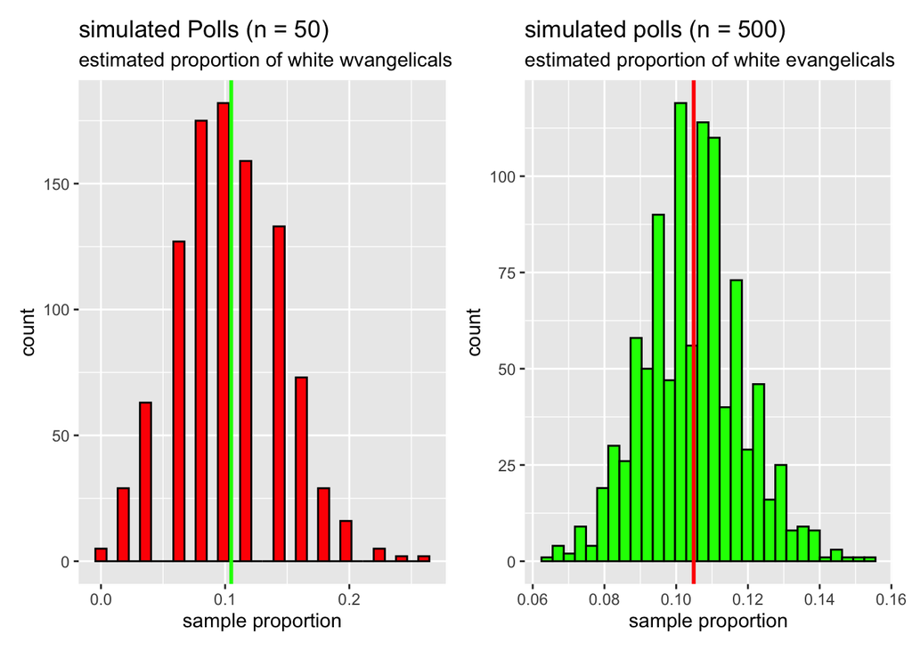

```r
library(ggplot2)
library(patchwork)

hist_50 <- ggplot(simulations_50, aes(x = proportion)) +
  geom_histogram(bins = 30, fill = "red", color = "black") +
  geom_vline(xintercept = population_proportion, color = "green", linewidth = 1) +
  labs(
    title = "simulated Polls (n = 50)",
    subtitle = "estimated proportion of white wvangelicals",
    x = "sample proportion",
    y = "count"
  )

hist_500 <- ggplot(simulations_500, aes(x = proportion)) +
  geom_histogram(bins = 30, fill = "green", color = "black") +
  geom_vline(xintercept = population_proportion, color = "red", linewidth = 1) +
  labs(
    title = "simulated polls (n = 500)",
    subtitle = "estimated proportion of white evangelicals",
    x = "sample proportion",
    y = "count"
  )

# Combine the plots side by side
hist_50 + hist_500
```

### Task 8: Reflect on what you see

**Describe the shape of the n=50 histogram.** Is it as symmetric as the unaffiliated histogram from class? Why do you think that is, given that White Evangelicals make up only about 10% of the population?

The n = 50 is wider and more uneven than being symmetric. I think this happened because WE’s make up only around 10% of the population so in a small sample there are likely to be less WE’s who respond. This means the population chnages a lot depending on the size of the sample. This has led in this case to a skewed distribution unlike the other.

**Compare the n=50 and n=500 histograms for this group.** How much does the distribution change with a larger sample? Is the improvement bigger or smaller than what you saw in class with the unaffiliated group?

The 500 person one is narrower and more concentratd in one the true proportion. This is because larger samples reduce random variation and are more reliable for this reason.

**A news organization wants to report on White Evangelical voters using a poll of 200 people.** Based on your simulations, roughly how many White Evangelical respondents would that poll be likely to include? What does that suggest about the reliability of estimates for smaller subgroups?

Based on the results I’ve seen a poll of 200 people would include around 20 WE respondents. Since this is a small number the answers would be less reliable.

**Imagine you are covering the 2028 presidential election and a campaign shares a poll showing White Evangelical support at 78%.** The poll sampled 400 people. Based on everything you’ve seen in this assignment and in class, what would you want to know before reporting that number?

Before reporting on a number like this I would want to know how many WE’s were included in the sample and if any weight were applied to adjust the demographics. I would look at how it compares to the other polls to see if the result is consistent.

When finished, save your work, switch to GitHub Desktop, then add, commit and push your changes to GitHub and submit the URL of the notebook in ELMS.